# CC Modeling

Chris Joyce

2025

# Objective

### This notebook focuses on applying different modeling methods to find interesting relationships between customers and their ordering habits. Specifically, we utilize unsupervised methods such as clustering to seek out common characteristics for customers who tend to have similar order patterns, and apply these methods based on monthly and yearly order totals. We continue to emphasize the two customer groups of interest, gallon-only Local Market Partners, and all customers, created in the EDA notebook.

# Load in and prep

```r
setwd("F:/Lori/Downloads")
m <- read.csv('merged_data.csv')
```

```r
# Type casting character variables into factors, and binary variables as logical
m_chrs <- m[, c(5, 13, 16, 17, 18)]
m_chrs <- lapply(m_chrs, as.factor)
m_chrs <- as.data.frame(m_chrs)

m[, c(5, 13, 16, 17, 18)] <- m_chrs

m_log <- m[, c(19, 20)]
m_log <- lapply(m_log, as.logical)
m_log <- as.data.frame(m_log)

m[, c(19, 20)] <- m_log

m <- m |>
  mutate(Has.Primary.Group.Number. = as.factor(Has.Primary.Group.Number.))
```

```r
m <- m %>%
  separate(full.address, into = c("zip", "city", "state", "state_abbr", "county", "county_code", "longitude", "latitude"), sep = ",")
```

```r
# Separating latitude and longitude data from address column
m <- m %>%
  mutate(coordinates = paste(latitude, longitude, sep = ","))

m$latitude <- as.numeric(m$latitude)
m$longitude <- as.numeric(m$longitude)
```

```r
#str(m)
#summary(m)
```

```r
# LMP group
LMP_distinct <- m |>
  filter(LOCAL_MARKET_PARTNER == TRUE, CO2_CUSTOMER == FALSE, ORDERED_CASES == 0, LOADED_CASES == 0, DELIVERED_CASES == 0)
  #summarize(case_avg = mean(ORDERED_CASES), gallon_avg = mean(ORDERED_GALLONS), total_avg = case_avg + gallon_avg) |>
  #arrange(case_avg)
head(LMP_distinct)
```

```
##   TRANSACTION_DATE WEEK YEAR CUSTOMER_NUMBER    ORDER_TYPE ORDERED_CASES
## 1        1/27/2023    4 2023       500245736   CALL CENTER             0
## 2         2/7/2023    6 2023       500286266 MYCOKE LEGACY             0
## 3         2/9/2023    6 2023       600256510     SALES REP             0
## 4        7/14/2023   28 2023       500331173   CALL CENTER             0
## 5         1/5/2024    1 2024       600262653   CALL CENTER             0
## 6        1/26/2024    4 2024       501261332 MYCOKE LEGACY             0
##   LOADED_CASES DELIVERED_CASES ORDERED_GALLONS LOADED_GALLONS DELIVERED_GALLONS
## 1            0               0            25.0           25.0              25.0
## 2            0               0            42.5           42.5              42.5
## 3            0               0            25.0           25.0              25.0
## 4            0               0             7.5            7.5               7.5
## 5            0               0             5.0            5.0               5.0
## 6            0               0            27.5           27.5              27.5
##   PRIMARY_GROUP_NUMBER FREQUENT_ORDER_TYPE FIRST_DELIVERY_DATE ON_BOARDING_DATE
```

[output cut: 48 more lines]

```r
# Aggregate yearly order data for LMP customer group
g1_y <- LMP_distinct %>%
  group_by(CUSTOMER_NUMBER, YEAR) %>%
  summarise(TOTAL_YEAR_ORDERS = sum(ORDERED_CASES + ORDERED_GALLONS, na.rm = TRUE),
            LATITUDE = first(latitude),
            LONGITUDE = first(longitude),
            PRIMARY_GROUP_NUMBER = first(PRIMARY_GROUP_NUMBER),
            LOCAL_MARKET_PARTNER = first(LOCAL_MARKET_PARTNER),
            FREQUENT_ORDER_TYPE = first(FREQUENT_ORDER_TYPE),
            COLD_DRINK_CHANNEL = first(COLD_DRINK_CHANNEL),
            TRADE_CHANNEL = first(TRADE_CHANNEL),
            SUB_TRADE_CHANNEL = first(SUB_TRADE_CHANNEL),
            TRANSACTION_DATE = first(TRANSACTION_DATE),
            Month = first(Month),
            Has.Primary.Group.Number. = first(Has.Primary.Group.Number.),
            .groups = 'drop') %>%
  ungroup()

head(g1_y)
```

```
## # A tibble: 6 × 14
##   CUSTOMER_NUMBER  YEAR TOTAL_YEAR_ORDERS LATITUDE LONGITUDE
##             <int> <int>             <dbl>    <dbl>     <dbl>
## 1       500245689  2023              40      -89.0      36.7
## 2       500245689  2024              52.5    -89.0      36.7
## 3       500245726  2023              60      -76.6      38.8
## 4       500245726  2024              30      -76.6      38.8
## 5       500245736  2023             438.     -71.8      42.6
## 6       500245736  2024             420      -71.8      42.6
## # ℹ 9 more variables: PRIMARY_GROUP_NUMBER <int>, LOCAL_MARKET_PARTNER <lgl>,
## #   FREQUENT_ORDER_TYPE <fct>, COLD_DRINK_CHANNEL <fct>, TRADE_CHANNEL <fct>,
## #   SUB_TRADE_CHANNEL <fct>, TRANSACTION_DATE <chr>, Month <int>,
## #   Has.Primary.Group.Number. <fct>
```

```r
# Aggregated orders for each year (all customers)
g2_y <- m |>
  select(CUSTOMER_NUMBER, zip, PRIMARY_GROUP_NUMBER, LOCAL_MARKET_PARTNER, CO2_CUSTOMER, FREQUENT_ORDER_TYPE, COLD_DRINK_CHANNEL,
         TRADE_CHANNEL, SUB_TRADE_CHANNEL, TRANSACTION_DATE, ORDERED_CASES, ORDERED_GALLONS, Month, Has.Primary.Group.Number., YEAR,
         latitude, longitude) |>
  group_by(CUSTOMER_NUMBER, YEAR) |>
  summarise(TOTAL_YEAR_ORDERS = sum(ORDERED_CASES + ORDERED_GALLONS, na.rm = TRUE),
            LATITUDE = first(latitude),
            LONGITUDE = first(longitude),
            PRIMARY_GROUP_NUMBER = first(PRIMARY_GROUP_NUMBER),
            LOCAL_MARKET_PARTNER = first(LOCAL_MARKET_PARTNER),
            CO2_CUSTOMER = first(CO2_CUSTOMER),
            FREQUENT_ORDER_TYPE = first(FREQUENT_ORDER_TYPE),
            COLD_DRINK_CHANNEL = first(COLD_DRINK_CHANNEL),
            TRADE_CHANNEL = first(TRADE_CHANNEL),
            SUB_TRADE_CHANNEL = first(SUB_TRADE_CHANNEL),
            TRANSACTION_DATE = first(TRANSACTION_DATE),
            Month = first(Month),
            Has.Primary.Group.Number. = first(Has.Primary.Group.Number.),
            .groups = 'drop') |>
  ungroup()

head(g2_y)
```

```
## # A tibble: 6 × 15
##   CUSTOMER_NUMBER  YEAR TOTAL_YEAR_ORDERS LATITUDE LONGITUDE
##             <int> <int>             <dbl>    <dbl>     <dbl>
## 1       500245678  2023             370      -96.6      39.8
## 2       500245678  2024             384.     -96.6      39.8
## 3       500245685  2023             602.     -75.9      39.4
## 4       500245685  2024             482      -75.9      39.4
## 5       500245686  2023              17.5    -73.0      42.7
## 6       500245686  2024              18.5    -73.0      42.7
## # ℹ 10 more variables: PRIMARY_GROUP_NUMBER <int>, LOCAL_MARKET_PARTNER <lgl>,
## #   CO2_CUSTOMER <lgl>, FREQUENT_ORDER_TYPE <fct>, COLD_DRINK_CHANNEL <fct>,
## #   TRADE_CHANNEL <fct>, SUB_TRADE_CHANNEL <fct>, TRANSACTION_DATE <chr>,
## #   Month <int>, Has.Primary.Group.Number. <fct>
```

```r
# Aggregate monthly orders for all customers
g2_m <- m |>
  group_by(Month, CUSTOMER_NUMBER) |>
  summarise(ORDERED_GALLONS = sum(ORDERED_GALLONS, na.rm = TRUE),
            ORDERED_CASES = sum(ORDERED_CASES, na.rm = TRUE),
            MONTHLY_TOTAL = sum(ORDERED_GALLONS + ORDERED_CASES, na.rm = TRUE),
            zip = first(zip),
            PRIMARY_GROUP_NUMBER = first(PRIMARY_GROUP_NUMBER),
            LOCAL_MARKET_PARTNER = first(LOCAL_MARKET_PARTNER),
            CO2_CUSTOMER = first(CO2_CUSTOMER),
            FREQUENT_ORDER_TYPE = first(FREQUENT_ORDER_TYPE),
            COLD_DRINK_CHANNEL = first(COLD_DRINK_CHANNEL),
            TRADE_CHANNEL = first(TRADE_CHANNEL),
            SUB_TRADE_CHANNEL = first(SUB_TRADE_CHANNEL),
            TRANSACTION_DATE = first(TRANSACTION_DATE),
            Has.Primary.Group.Number. = first(Has.Primary.Group.Number.),
            YEAR = first(YEAR),
            .groups = 'drop') |>
  ungroup()
```

```r
# Aggregate monthly gallon orders for LMP group
g1_m <- LMP_distinct |>
  group_by(Month, CUSTOMER_NUMBER) |>
  summarise(ORDERED_GALLONS = sum(ORDERED_GALLONS, na.rm = TRUE),
            zip = first(zip),
            PRIMARY_GROUP_NUMBER = first(PRIMARY_GROUP_NUMBER),
            FREQUENT_ORDER_TYPE = first(FREQUENT_ORDER_TYPE),
            COLD_DRINK_CHANNEL = first(COLD_DRINK_CHANNEL),
            TRADE_CHANNEL = first(TRADE_CHANNEL),
            SUB_TRADE_CHANNEL = first(SUB_TRADE_CHANNEL),
            TRANSACTION_DATE = first(TRANSACTION_DATE),
            Has.Primary.Group.Number. = first(Has.Primary.Group.Number.),
            YEAR = first(YEAR),
            .groups = 'drop') |>
  ungroup()
```

```r
head(g1_m)
```

```
## # A tibble: 6 × 12
##   Month CUSTOMER_NUMBER ORDERED_GALLONS zip   PRIMARY_GROUP_NUMBER
##   <int>           <int>           <dbl> <chr>                <int>
## 1     1       500245689            22.5 42031                   NA
## 2     1       500245726             7.5 20751                   NA
## 3     1       500245736           100   01420                   NA
## 4     1       500245740            19.2 01373                 1835
## 5     1       500245824            32.5 67520                   NA
## 6     1       500245826            35   21788                   NA
## # ℹ 7 more variables: FREQUENT_ORDER_TYPE <fct>, COLD_DRINK_CHANNEL <fct>,
## #   TRADE_CHANNEL <fct>, SUB_TRADE_CHANNEL <fct>, TRANSACTION_DATE <chr>,
## #   Has.Primary.Group.Number. <fct>, YEAR <int>
```

# Supplemental EDA

```r
# Average yearly orders for each trade channel (LMP group)
g1_y |>
  select(TOTAL_YEAR_ORDERS, TRADE_CHANNEL) |>
  group_by(TRADE_CHANNEL) |>
  summarise(y_avg = mean(TOTAL_YEAR_ORDERS, na.rm = TRUE),
            .groups = 'drop') |>
  arrange(desc(y_avg))
```

```
## # A tibble: 24 × 2
##    TRADE_CHANNEL           y_avg
##    <fct>                   <dbl>
##  1 BULK TRADE               609.
##  2 COMPREHENSIVE DINING     340.
##  3 ACTIVITIES               332.
##  4 INDUSTRIAL               328.
##  5 FAST CASUAL DINING       272.
##  6 RECREATION               271.
##  7 HEALTHCARE               214.
##  8 OTHER DINING & BEVERAGE  186.
##  9 LICENSED HOSPITALITY     171.
## 10 OUTDOOR ACTIVITIES       148.
## # ℹ 14 more rows
```

```r
# Average yearly orders for each trade channel (all customers)
g2_y |>
  select(TOTAL_YEAR_ORDERS, TRADE_CHANNEL) |>
  group_by(TRADE_CHANNEL) |>
  summarise(y_avg = mean(TOTAL_YEAR_ORDERS, na.rm = TRUE),
            .groups = 'drop') |>
  arrange(desc(y_avg))
```

```
## # A tibble: 26 × 2
##    TRADE_CHANNEL                 y_avg
##    <fct>                         <dbl>
##  1 TRAVEL                       21746.
##  2 BULK TRADE                    7601.
##  3 SUPERSTORE                    7375.
##  4 GENERAL                       3297.
##  5 ACTIVITIES                    2514.
##  6 ACADEMIC INSTITUTION          1431.
##  7 HEALTHCARE                    1385.
##  8 RECREATION                    1100.
##  9 DEFENSE                        693.
## 10 PUBLIC SECTOR (NON-MILITARY)   614.
## # ℹ 16 more rows
```

```r
# Average monthly orders for each trade channel (LMP group)
g1_m |>
  select(ORDERED_GALLONS, TRADE_CHANNEL) |>
  group_by(TRADE_CHANNEL) |>
  summarise(m_avg = mean(ORDERED_GALLONS, na.rm = TRUE),
            .groups = 'drop') |>
  arrange(desc(m_avg))
```

```
## # A tibble: 24 × 2
##    TRADE_CHANNEL           m_avg
##    <fct>                   <dbl>
##  1 BULK TRADE              265.
##  2 RECREATION               98.2
##  3 INDUSTRIAL               89.3
##  4 COMPREHENSIVE DINING     74.8
##  5 ACTIVITIES               73.7
##  6 FAST CASUAL DINING       66.7
##  7 HEALTHCARE               61.4
##  8 GENERAL RETAILER         57.8
##  9 OUTDOOR ACTIVITIES       52.5
## 10 OTHER DINING & BEVERAGE  50.4
## # ℹ 14 more rows
```

```r
# Average monthly orders for each trade channel (all customers)
g2_m |>
  select(MONTHLY_TOTAL, TRADE_CHANNEL) |>
  group_by(TRADE_CHANNEL) |>
  summarise(m_avg = mean(MONTHLY_TOTAL, na.rm = TRUE),
            .groups = 'drop') |>
  arrange(desc(m_avg))
```

```
## # A tibble: 26 × 2
##    TRADE_CHANNEL        m_avg
##    <fct>                <dbl>
##  1 TRAVEL               4155.
##  2 BULK TRADE           1398.
##  3 SUPERSTORE           1254.
##  4 GENERAL               610.
##  5 ACTIVITIES            488.
##  6 ACADEMIC INSTITUTION  296.
##  7 RECREATION            294.
##  8 HEALTHCARE            255.
##  9 OUTDOOR ACTIVITIES    137.
## 10 DEFENSE               135.
## # ℹ 16 more rows
```

```r
# Calculate percentiles for TOTAL_YEAR_ORDERS
g1_y_percentiles <- quantile(g1_y$TOTAL_YEAR_ORDERS, probs = seq(0, 1, 0.01), na.rm = TRUE)

# View the percentiles
g1_y_percentiles
```

```
##          0%          1%          2%          3%          4%          5%
##    0.000000    0.000000    0.000000    0.000000    3.617731    5.000000
##          6%          7%          8%          9%         10%         11%
##    5.000000    7.500000   10.000000   10.000000   12.500000   12.500000
##         12%         13%         14%         15%         16%         17%
##   15.000000   15.000000   17.500000   20.000000   20.000000   22.500000
##         18%         19%         20%         21%         22%         23%
##   22.500000   25.000000   25.000000   27.500000   27.500000   30.000000
##         24%         25%         26%         27%         28%         29%
##   30.400000   32.500000   35.000000   37.500000   40.000000   40.000000
##         30%         31%         32%         33%         34%         35%
##   42.500000   45.000000   47.421194   47.500000   50.000000   52.500000
##         36%         37%         38%         39%         40%         41%
##   55.000000   60.000000   62.500000   65.000000   67.500000   70.000000
##         42%         43%         44%         45%         46%         47%
##   72.500000   75.000000   80.000000   83.792007   87.500000   90.000000
##         48%         49%         50%         51%         52%         53%
##   92.500000   97.500000  100.000000  105.000000  110.000000  115.000000
##         54%         55%         56%         57%         58%         59%
##  117.500000  122.500000  127.500000  135.000000  140.000000  145.000000
##         60%         61%         62%         63%         64%         65%
##  150.000000  155.000000  161.600941  167.500000  172.500000  180.000000
##         66%         67%         68%         69%         70%         71%
##  187.500000  195.075000  205.000000  215.000000  222.500000  230.975000
##         72%         73%         74%         75%         76%         77%
##  243.700000  255.000000  265.000000  275.000000  285.000000  297.500000
##         78%         79%         80%         81%         82%         83%
##  312.500000  327.500000  342.500000  362.500000  380.000000  398.675000
##         84%         85%         86%         87%         88%         89%
##  420.000000  440.000000  464.785700  502.075000  527.500000  557.500000
##         90%         91%         92%         93%         94%         95%
##  605.000000  647.500000  690.700000  753.425000  808.650000  896.375000
##         96%         97%         98%         99%        100%
##  997.500000 1152.500000 1317.050000 1934.550000 8402.500000
```

```r
g2_y_percentiles <- quantile(g2_y$TOTAL_YEAR_ORDERS, probs = seq(0, 1, 0.01), na.rm = TRUE)

g2_y_percentiles
```

```
##          0%          1%          2%          3%          4%          5%
##      0.0000      2.5000      6.0000     10.0000     12.0000     15.0000
##          6%          7%          8%          9%         10%         11%
##     17.5000     20.0000     22.5000     25.0000     27.5000     30.0000
##         12%         13%         14%         15%         16%         17%
##     32.0000     35.0000     37.0000     40.0000     42.0000     45.0000
##         18%         19%         20%         21%         22%         23%
##     47.5000     50.0000     53.0000     55.5000     59.0000     61.5000
##         24%         25%         26%         27%         28%         29%
##     64.0000     67.0000     70.0000     72.5000     76.0000     79.5000
##         30%         31%         32%         33%         34%         35%
##     82.5000     86.0000     89.5000     92.5000     96.0000    100.0000
##         36%         37%         38%         39%         40%         41%
##    103.5000    107.5000    111.5000    115.0000    120.0000    124.0000
##         42%         43%         44%         45%         46%         47%
##    128.0000    133.0000    138.0000    143.0000    147.5000    152.5000
##         48%         49%         50%         51%         52%         53%
##    158.9192    164.5000    170.0000    176.5000    183.0000    190.5000
##         54%         55%         56%         57%         58%         59%
##    197.5000    205.0000    212.5000    220.5000    229.0000    237.5000
##         60%         61%         62%         63%         64%         65%
##    247.5000    257.9300    268.0000    279.0000    290.0000    302.5000
##         66%         67%         68%         69%         70%         71%
##    315.0000    327.9833    341.0000    355.0000    370.0000    384.5000
##         72%         73%         74%         75%         76%         77%
##    400.5000    418.0000    437.5000    457.5000    478.5000    500.0000
##         78%         79%         80%         81%         82%         83%
##    526.5000    554.0200    584.0000    617.0000    651.5000    694.0000
##         84%         85%         86%         87%         88%         89%
##    736.1700    786.0000    837.5000    893.0000    961.0000   1034.0000
##         90%         91%         92%         93%         94%         95%
##   1122.4000   1228.1600   1350.9200   1513.6800   1694.3800   1950.4000
##         96%         97%         98%         99%        100%
##   2322.1700   2888.6000   4009.4000   7467.6900 459175.7404
```

```r
# Calculate percentiles for monthly orders
g1_m_percentiles <- quantile(g1_m$ORDERED_GALLONS, probs = seq(0, 1, 0.01), na.rm = TRUE)

g1_m_percentiles
```

```
##         0%         1%         2%         3%         4%         5%         6%
##    0.00000    0.52095    2.50000    5.00000    5.00000    5.00000    5.00000
##         7%         8%         9%        10%        11%        12%        13%
##    7.50000    7.50000    7.50000    7.50000   10.00000   10.00000   10.00000
##        14%        15%        16%        17%        18%        19%        20%
##   10.00000   12.07637   12.50000   12.50000   12.50000   15.00000   15.00000
##        21%        22%        23%        24%        25%        26%        27%
##   15.00000   15.00000   15.00000   17.50000   17.50000   17.50000   17.50000
##        28%        29%        30%        31%        32%        33%        34%
##   17.50000   20.00000   20.00000   20.00000   20.00000   20.28860   22.50000
##        35%        36%        37%        38%        39%        40%        41%
##   22.50000   22.50000   25.00000   25.00000   25.00000   25.00000   27.50000
##        42%        43%        44%        45%        46%        47%        48%
##   27.50000   27.50000   30.00000   30.00000   30.00000   32.50000   32.50000
##        49%        50%        51%        52%        53%        54%        55%
##   32.50000   35.00000   35.00000   35.00000   37.50000   37.50000   40.00000
##        56%        57%        58%        59%        60%        61%        62%
##   40.00000   40.00000   42.50000   42.50000   45.00000   45.00000   47.50000
##        63%        64%        65%        66%        67%        68%        69%
##   47.50000   50.00000   52.50000   52.50000   55.00000   57.50000   57.50000
##        70%        71%        72%        73%        74%        75%        76%
##   60.00000   62.50000   65.00000   65.00000   67.50000   70.00000   72.50000
##        77%        78%        79%        80%        81%        82%        83%
##   75.00000   80.00000   82.50000   85.00000   87.50000   92.50000   95.00000
##        84%        85%        86%        87%        88%        89%        90%
##  100.00000  105.00000  110.00000  115.00000  120.00000  127.50000  135.00000
##        91%        92%        93%        94%        95%        96%        97%
##  142.50000  152.50000  162.50000  175.00000  190.00000  207.50000  237.50000
##        98%        99%       100%
##  280.35000  382.50000 4000.00000
```

```r
g2_m_percentiles <- quantile(g2_m$MONTHLY_TOTAL, probs = seq(0, 1, 0.01), na.rm = TRUE)

g2_m_percentiles
```

```
##          0%          1%          2%          3%          4%          5%
##     0.00000     2.50000     3.50000     5.00000     5.00000     5.00000
##          6%          7%          8%          9%         10%         11%
##     6.00000     7.00000     7.50000     8.00000     9.00000     9.50000
##         12%         13%         14%         15%         16%         17%
##    10.00000    10.00000    10.50000    11.00000    12.00000    12.50000
##         18%         19%         20%         21%         22%         23%
##    13.00000    14.00000    15.00000    15.00000    15.00000    16.00000
##         24%         25%         26%         27%         28%         29%
##    17.00000    17.50000    18.00000    19.00000    19.75094    20.00000
##         30%         31%         32%         33%         34%         35%
##    20.00000    21.00000    22.00000    22.50000    23.50000    24.50000
##         36%         37%         38%         39%         40%         41%
##    25.00000    25.50000    27.00000    27.50000    28.50000    29.50000
##         42%         43%         44%         45%         46%         47%
##    30.00000    31.00000    32.50000    33.00000    34.00000    35.00000
##         48%         49%         50%         51%         52%         53%
##    36.00000    37.50000    38.50000    40.00000    41.00000    42.50000
##         54%         55%         56%         57%         58%         59%
##    44.00000    45.00000    47.00000    48.00000    50.00000    51.50000
##         60%         61%         62%         63%         64%         65%
##    53.00000    55.00000    57.50000    59.00000    61.00000    63.00000
##         66%         67%         68%         69%         70%         71%
##    65.50000    68.00000    70.50000    73.50000    76.50000    80.00000
##         72%         73%         74%         75%         76%         77%
##    82.50000    86.00000    90.00000    94.00000    98.00000   102.50000
##         78%         79%         80%         81%         82%         83%
##   107.50000   113.00000   119.00000   125.00000   132.00000   139.50000
##         84%         85%         86%         87%         88%         89%
##   147.50000   156.50000   166.50000   177.50000   190.00000   204.00000
##         90%         91%         92%         93%         94%         95%
##   220.50000   240.00000   263.00000   293.00000   331.00000   385.00000
##         96%         97%         98%         99%        100%
##   461.00000   582.00000   815.00000  1549.00000 91920.00000
```

### We note the percentiles for yearly orders for customers in group 1 (LMP gallon only) and group 2 (all customers). 83.5% of customers in group 1 are below the existing 400 gallon per year threshold. 72% of customers in group 2 are below this threshold.

```r
# Extend the Month column
#g1_m <- g1_m |>
  #mutate(Month = ifelse(YEAR == 2023, Month, Month + 12))

# Sort the data by CUSTOMER_NUMBER and Extended_Month
#g1_m <- g1_m |>
  #arrange(Month)

#g1_m
```

```r
# Calculating growth index for LMP group with orders between  7.5 - 33.3 gals/month

# Sort the data by CUSTOMER_NUMBER, YEAR, and Month
g1_m_agi <- g1_m |>
  filter(ORDERED_GALLONS >= 7.5 & ORDERED_GALLONS <= 33.3) |>
  arrange(CUSTOMER_NUMBER, YEAR, Month)

# Calculate the month-by-month growth index as a percentage
g1_m_agi <- g1_m_agi |>
  group_by(CUSTOMER_NUMBER, YEAR) |>
  mutate(Previous_Month_Total = lag(ORDERED_GALLONS),
         Growth_Index = ifelse(Previous_Month_Total == 0, NA, (ORDERED_GALLONS - Previous_Month_Total) / Previous_Month_Total * 100)) |>
  ungroup()

# Handle NA values in Growth_Index
g1_m_agi <- g1_m_agi |>
  mutate(Growth_Index = ifelse(is.na(Growth_Index), 0, Growth_Index))

# Calculate the average monthly growth index for each customer for each year
average_growth_index <- g1_m_agi |>
  group_by(CUSTOMER_NUMBER, YEAR) |>
  summarise(Average_Growth_Index = mean(Growth_Index, na.rm = TRUE),
            .groups = 'drop')

# Select relevant columns and join the average growth index
g1_m_agi <- g1_m_agi |>
  select(CUSTOMER_NUMBER, zip, PRIMARY_GROUP_NUMBER, FREQUENT_ORDER_TYPE, COLD_DRINK_CHANNEL,
         TRADE_CHANNEL, SUB_TRADE_CHANNEL, Has.Primary.Group.Number., YEAR) |>
  distinct(CUSTOMER_NUMBER, YEAR, .keep_all = TRUE) |>
  left_join(average_growth_index, by = c("CUSTOMER_NUMBER", "YEAR")) |>
  arrange(desc(Average_Growth_Index))

g1_m_agi <- g1_m_agi |>
  mutate(AGI_GROUP = ifelse(Average_Growth_Index < 0, 0,
                            ifelse(Average_Growth_Index >= 5.5 & Average_Growth_Index <= 79, 1, NA)))
```

```r
# Calculating growth index for all customers with orders between 7.5 - 33.3 gals/month

# Sort the data by CUSTOMER_NUMBER, YEAR, and Month
g2_m_agi <- g2_m |>
  filter(ORDERED_GALLONS >= 7.5 & ORDERED_GALLONS <= 33.3) |>
  arrange(CUSTOMER_NUMBER, YEAR, Month)

# Calculate the month-by-month growth index as a percentage
g2_m_agi <- g2_m_agi |>
  group_by(CUSTOMER_NUMBER, YEAR) |>
  mutate(Previous_Month_Total = lag(MONTHLY_TOTAL),
         Growth_Index = ifelse(Previous_Month_Total == 0, NA, (MONTHLY_TOTAL - Previous_Month_Total) / Previous_Month_Total * 100)) |>
  ungroup()

# Handle NA values in Growth_Index (e.g., first month for each customer)
g2_m_agi <- g2_m_agi |>
  mutate(Growth_Index = ifelse(is.na(Growth_Index), 0, Growth_Index))

# Calculate the average monthly growth index for each customer for each year
average_growth_index <- g2_m_agi |>
  group_by(CUSTOMER_NUMBER, YEAR) |>
  summarise(Average_Growth_Index = mean(Growth_Index, na.rm = TRUE),
            .groups = 'drop')

# Select relevant columns and join the average growth index
g2_m_agi <- g2_m_agi |>
  select(CUSTOMER_NUMBER, zip, PRIMARY_GROUP_NUMBER, FREQUENT_ORDER_TYPE, COLD_DRINK_CHANNEL,
         TRADE_CHANNEL, SUB_TRADE_CHANNEL, Has.Primary.Group.Number., YEAR) |>
  distinct(CUSTOMER_NUMBER, YEAR, .keep_all = TRUE) |>
  left_join(average_growth_index, by = c("CUSTOMER_NUMBER", "YEAR")) |>
  arrange(desc(Average_Growth_Index))

g2_m_agi <- g2_m_agi |>
  mutate(AGI_GROUP = ifelse(Average_Growth_Index < 0, 0,
                            ifelse(Average_Growth_Index >= 5.5 & Average_Growth_Index <= 79, 1, NA)))
```

```r
# Merge based on 'customer_number'
g1_y <- merge(g1_y, g1_m_agi[, c('CUSTOMER_NUMBER', 'AGI_GROUP')], by = 'CUSTOMER_NUMBER', all.x = TRUE)

names(g1_y)[names(g1_y) == "AGI_GROUP.x"] <- "AGI_GROUP"
names(g1_y)[names(g1_y) == "AGI_GROUP.y"] <- "AGI_GROUP"
head(g1_y)
```

```
##   CUSTOMER_NUMBER YEAR TOTAL_YEAR_ORDERS LATITUDE LONGITUDE
## 1       500245689 2023              40.0 -88.9676   36.6675
## 2       500245689 2023              40.0 -88.9676   36.6675
## 3       500245689 2024              52.5 -88.9676   36.6675
## 4       500245689 2024              52.5 -88.9676   36.6675
## 5       500245726 2023              60.0 -76.5515   38.7829
## 6       500245726 2023              60.0 -76.5515   38.7829
##   PRIMARY_GROUP_NUMBER LOCAL_MARKET_PARTNER FREQUENT_ORDER_TYPE
## 1                   NA                 TRUE               OTHER
## 2                   NA                 TRUE               OTHER
## 3                   NA                 TRUE               OTHER
## 4                   NA                 TRUE               OTHER
## 5                   NA                 TRUE         CALL CENTER
## 6                   NA                 TRUE         CALL CENTER
##   COLD_DRINK_CHANNEL        TRADE_CHANNEL          SUB_TRADE_CHANNEL
## 1             DINING LICENSED HOSPITALITY OTHER LICENSED HOSPITALITY
## 2             DINING LICENSED HOSPITALITY OTHER LICENSED HOSPITALITY
## 3             DINING LICENSED HOSPITALITY OTHER LICENSED HOSPITALITY
## 4             DINING LICENSED HOSPITALITY OTHER LICENSED HOSPITALITY
## 5             DINING COMPREHENSIVE DINING                 FSR - MISC
## 6             DINING COMPREHENSIVE DINING                 FSR - MISC
##   TRANSACTION_DATE Month Has.Primary.Group.Number. AGI_GROUP
## 1        2/17/2023     2                         1         0
## 2        2/17/2023     2                         1         0
## 3        1/26/2024     1                         1         0
## 4        1/26/2024     1                         1         0
## 5       12/14/2023    12                         1         0
## 6       12/14/2023    12                         1         1
```

```r
# Merge based on 'customer_number'
g2_y <- merge(g2_y, g2_m_agi[, c('CUSTOMER_NUMBER', 'AGI_GROUP')], by = 'CUSTOMER_NUMBER', all.x = TRUE)

names(g2_y)[names(g2_y) == "AGI_GROUP.x"] <- "AGI_GROUP"
names(g2_y)[names(g2_y) == "AGI_GROUP.y"] <- "AGI_GROUP"
head(g2_y)
```

```
##   CUSTOMER_NUMBER YEAR TOTAL_YEAR_ORDERS LATITUDE LONGITUDE
## 1       500245678 2023             370.0 -96.6422   39.8428
## 2       500245678 2023             370.0 -96.6422   39.8428
## 3       500245678 2024             383.5 -96.6422   39.8428
## 4       500245678 2024             383.5 -96.6422   39.8428
## 5       500245685 2023             601.5 -75.8654   39.4015
## 6       500245685 2024             482.0 -75.8654   39.4015
##   PRIMARY_GROUP_NUMBER LOCAL_MARKET_PARTNER CO2_CUSTOMER FREQUENT_ORDER_TYPE
## 1                   NA                 TRUE         TRUE           SALES REP
## 2                   NA                 TRUE         TRUE           SALES REP
## 3                   NA                 TRUE         TRUE           SALES REP
## 4                   NA                 TRUE         TRUE           SALES REP
## 5                   NA                 TRUE         TRUE               OTHER
## 6                   NA                 TRUE         TRUE               OTHER
##   COLD_DRINK_CHANNEL      TRADE_CHANNEL        SUB_TRADE_CHANNEL
## 1              EVENT OUTDOOR ACTIVITIES OTHER OUTDOOR ACTIVITIES
## 2              EVENT OUTDOOR ACTIVITIES OTHER OUTDOOR ACTIVITIES
## 3              EVENT OUTDOOR ACTIVITIES OTHER OUTDOOR ACTIVITIES
## 4              EVENT OUTDOOR ACTIVITIES OTHER OUTDOOR ACTIVITIES
## 5             DINING FAST CASUAL DINING          PIZZA FAST FOOD
## 6             DINING FAST CASUAL DINING          PIZZA FAST FOOD
##   TRANSACTION_DATE Month Has.Primary.Group.Number. AGI_GROUP
## 1         5/2/2023     5                         1        NA
## 2         5/2/2023     5                         1         0
## 3        8/26/2024     8                         1        NA
## 4        8/26/2024     8                         1         0
## 5         4/7/2023     4                         1        NA
## 6        2/23/2024     2                         1        NA
```

```r
g1_m_agi_percentiles <- quantile(g1_m_agi$Average_Growth_Index, probs = seq(0, 1, 0.01), na.rm = TRUE)

g1_m_agi_percentiles
```

```
##            0%            1%            2%            3%            4%
## -3.846154e+01 -3.181818e+01 -2.751748e+01 -2.500000e+01 -2.272727e+01
##            5%            6%            7%            8%            9%
## -2.004196e+01 -1.884444e+01 -1.666667e+01 -1.620852e+01 -1.428718e+01
##           10%           11%           12%           13%           14%
## -1.250000e+01 -1.111948e+01 -1.000000e+01 -9.585101e+00 -8.333333e+00
##           15%           16%           17%           18%           19%
## -7.684615e+00 -6.320000e+00 -5.555556e+00 -5.000000e+00 -4.166667e+00
##           20%           21%           22%           23%           24%
## -3.139276e+00 -2.083333e+00 -7.613544e-01  0.000000e+00  0.000000e+00
##           25%           26%           27%           28%           29%
##  0.000000e+00  0.000000e+00  0.000000e+00  0.000000e+00  0.000000e+00
##           30%           31%           32%           33%           34%
##  0.000000e+00  0.000000e+00  0.000000e+00  0.000000e+00  0.000000e+00
##           35%           36%           37%           38%           39%
##  0.000000e+00  0.000000e+00  0.000000e+00  0.000000e+00  0.000000e+00
##           40%           41%           42%           43%           44%
##  0.000000e+00  0.000000e+00  0.000000e+00  0.000000e+00  0.000000e+00
##           45%           46%           47%           48%           49%
##  0.000000e+00  0.000000e+00  0.000000e+00  0.000000e+00  0.000000e+00
##           50%           51%           52%           53%           54%
##  0.000000e+00  0.000000e+00  0.000000e+00  0.000000e+00  0.000000e+00
##           55%           56%           57%           58%           59%
##  0.000000e+00  0.000000e+00  0.000000e+00  0.000000e+00  0.000000e+00
##           60%           61%           62%           63%           64%
##  0.000000e+00  0.000000e+00  0.000000e+00  0.000000e+00  1.624494e-16
##           65%           66%           67%           68%           69%
##  9.770924e-01  1.948571e+00  2.777778e+00  3.809524e+00  4.571225e+00
##           70%           71%           72%           73%           74%
##  5.555556e+00  6.250000e+00  7.354015e+00  8.333333e+00  8.932418e+00
##           75%           76%           77%           78%           79%
##  9.722222e+00  1.021767e+01  1.111111e+01  1.236017e+01  1.312248e+01
##           80%           81%           82%           83%           84%
##  1.431688e+01  1.555556e+01  1.666667e+01  1.693122e+01  1.858022e+01
##           85%           86%           87%           88%           89%
##  1.992158e+01  2.122833e+01  2.297037e+01  2.500000e+01  2.661145e+01
##           90%           91%           92%           93%           94%
##  2.951852e+01  3.148519e+01  3.333333e+01  3.666667e+01  4.000000e+01
##           95%           96%           97%           98%           99%
##  4.431136e+01  5.000000e+01  5.555556e+01  6.666667e+01  7.956667e+01
##          100%
##  1.500000e+02
```

```r
g2_m_agi_percentiles <- quantile(g2_m_agi$Average_Growth_Index, probs = seq(0, 1, 0.01), na.rm = TRUE)

g2_m_agi_percentiles
```

```
##            0%            1%            2%            3%            4%
## -4.817851e+01 -3.168445e+01 -2.777778e+01 -2.500000e+01 -2.260071e+01
##            5%            6%            7%            8%            9%
## -2.027972e+01 -1.884169e+01 -1.689748e+01 -1.573658e+01 -1.410835e+01
##           10%           11%           12%           13%           14%
## -1.277778e+01 -1.180556e+01 -1.082818e+01 -9.840659e+00 -8.730159e+00
##           15%           16%           17%           18%           19%
## -7.924629e+00 -7.037037e+00 -6.111111e+00 -5.374734e+00 -4.545455e+00
##           20%           21%           22%           23%           24%
## -4.000000e+00 -3.196483e+00 -2.440139e+00 -1.759447e+00 -1.019407e+00
##           25%           26%           27%           28%           29%
## -1.830225e-01  0.000000e+00  0.000000e+00  0.000000e+00  0.000000e+00
##           30%           31%           32%           33%           34%
##  0.000000e+00  0.000000e+00  0.000000e+00  0.000000e+00  0.000000e+00
##           35%           36%           37%           38%           39%
##  0.000000e+00  0.000000e+00  0.000000e+00  0.000000e+00  0.000000e+00
##           40%           41%           42%           43%           44%
##  0.000000e+00  0.000000e+00  0.000000e+00  0.000000e+00  0.000000e+00
##           45%           46%           47%           48%           49%
##  0.000000e+00  0.000000e+00  0.000000e+00  0.000000e+00  0.000000e+00
##           50%           51%           52%           53%           54%
##  0.000000e+00  0.000000e+00  0.000000e+00  0.000000e+00  0.000000e+00
##           55%           56%           57%           58%           59%
##  0.000000e+00  1.705164e-15  7.597705e-01  1.403128e+00  2.083333e+00
##           60%           61%           62%           63%           64%
##  2.777778e+00  3.430569e+00  4.166667e+00  4.687101e+00  5.350054e+00
##           65%           66%           67%           68%           69%
##  5.925926e+00  6.666667e+00  7.268398e+00  8.053230e+00  8.750000e+00
##           70%           71%           72%           73%           74%
##  9.523810e+00  1.012997e+01  1.090909e+01  1.155995e+01  1.243495e+01
##           75%           76%           77%           78%           79%
##  1.315645e+01  1.408362e+01  1.503385e+01  1.600000e+01  1.666667e+01
##           80%           81%           82%           83%           84%
##  1.755952e+01  1.875000e+01  1.977511e+01  2.083333e+01  2.208333e+01
##           85%           86%           87%           88%           89%
##  2.347243e+01  2.500000e+01  2.634409e+01  2.833333e+01  3.000000e+01
##           90%           91%           92%           93%           94%
##  3.203125e+01  3.388889e+01  3.669079e+01  3.955370e+01  4.285714e+01
##           95%           96%           97%           98%           99%
##  4.776389e+01  5.185185e+01  6.111111e+01  7.211982e+01  9.617074e+01
##          100%
##  2.550000e+03
```

### We calculate percentiles of growth index values for the aforementioned groups. 30% of customers in group 1 show promising month by month growth (5.5 - 79%). 34% of customers in group 2 show between 6% and 96% month by month growth. Thus, we will focus on these specific customers who show consistent positive growth and assign them binary values to indicate positive or negative growth. Note that these monthly order percentiles are exclusively for customers who are below the existing 400 gallon per year threshold across both groups.

```r
# Assigning AGI group values based on monthly growth index
g1_m_agi <- g1_m_agi %>%
  mutate(AGI_GROUP = ifelse(Average_Growth_Index < 0, 0,
                            ifelse(Average_Growth_Index >= 5.5 & Average_Growth_Index <= 79, 1, NA))) # 0 for declining AGI, 1 for low-medium AGI, NA for customers greatly surpassing threshold

g2_m_agi <- g2_m_agi |>
  mutate(AGI_GROUP = ifelse(Average_Growth_Index < 0, 0,
                            ifelse(Average_Growth_Index >= 6  & Average_Growth_Index <= 96, 1, NA)))
```

# K - Prototype Clustering for Customers Ordering Within 400 gallons/year

```r
# Cluster for LMP within threshold
g1_m_cluster_1 <- g1_m_agi |>
  select(FREQUENT_ORDER_TYPE, COLD_DRINK_CHANNEL,
         TRADE_CHANNEL, SUB_TRADE_CHANNEL, AGI_GROUP, Average_Growth_Index) |>
  filter(AGI_GROUP == 1)

# Scale numerical variables using min-max scaling
#g1_m_cluster_1 <- g1_m_cluster_1 |>
  #mutate(Average_Growth_Index = (Average_Growth_Index - min(Average_Growth_Index)) / (max(Average_Growth_Index) - min(Average_Growth_Index)))
```

```r
# Calculate WCSS for different numbers of clusters
set.seed(22)
wcss <- numeric(15)
for (k in 1:15) {
  kpres <- kproto(g1_m_cluster_1, k)
  wcss[k] <- kpres$tot.withinss
}
```

[output not shown]

[output cut: 79 more lines]

[output not shown]

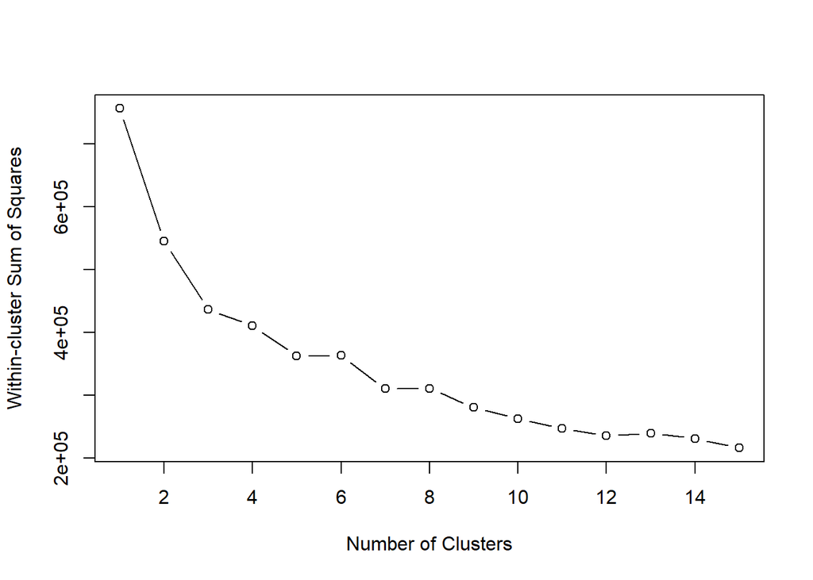

```r
# Plot the Elbow graph
plot(1:15, wcss, type = "b", xlab = "Number of Clusters", ylab = "Within-cluster Sum of Squares")
```

```r
set.seed(22)

kpres <- kproto(g1_m_cluster_1, k = 7)  # Adjust 'k' to the desired number of clusters
```

```
## # NAs in variables:
##  FREQUENT_ORDER_TYPE   COLD_DRINK_CHANNEL        TRADE_CHANNEL
##                    0                    0                    0
##    SUB_TRADE_CHANNEL            AGI_GROUP Average_Growth_Index
##                    0                    0                    0
## 0 observation(s) with NAs.
##
## Estimated lambda: 227.2281
```

```r
summary(kpres)
```

```
## FREQUENT_ORDER_TYPE
##
## cluster CALL CENTER   EDI MYCOKE LEGACY MYCOKE360 OTHER SALES REP
##       1       0.064 0.000         0.019     0.058 0.160     0.699
##       2       0.000 0.000         0.000     0.040 0.220     0.740
##       3       0.036 0.000         0.013     0.108 0.157     0.686
##       4       0.065 0.000         0.025     0.040 0.186     0.683
##       5       0.036 0.000         0.043     0.072 0.115     0.734
##       6       0.064 0.000         0.013     0.030 0.172     0.721
##       7       0.036 0.000         0.018     0.161 0.554     0.232
##
## -----------------------------------------------------------------
## COLD_DRINK_CHANNEL
##
## cluster ACCOMMODATION BULK TRADE CONVENTIONAL DINING EVENT GOODS PUBLIC SECTOR
```

[output cut: 226 more lines]

```r
g1_m_cluster_1$Cluster <- kpres$cluster
```

```r
#g1mc1_summary_output <- capture.output(summary(kpres))

#writeLines(g1mc1_summary_output, "g1mc1_cluster_summary.txt")
```

```r
# Create boxplot
#ggplot(g1_m_cluster, aes(x = factor(Cluster), y = Average_Growth_Index)) +
  #geom_boxplot() +
  #labs(x = "Cluster Number", y = "AGI") +
  #theme_minimal()
```

```r
#ggplot(g1_m_cluster, aes(x = FREQUENT_ORDER_TYPE, y = Average_Growth_Index, color = factor(Cluster))) +
  #geom_point() +
  #labs(x = "FREQUENT_ORDER_TYPE", y = "AGI", color = "Cluster") +
  #theme_minimal()
```

```r
# Cluster for LMP within threshold, AGI < 0
g1_m_cluster_0 <- g1_m_agi |>
  select(FREQUENT_ORDER_TYPE, COLD_DRINK_CHANNEL, Has.Primary.Group.Number.,
         TRADE_CHANNEL, SUB_TRADE_CHANNEL, AGI_GROUP, Average_Growth_Index) |>
  filter(AGI_GROUP == 0)

# Scale numerical variables using min-max scaling
#g1_m_cluster_0 <- g1_m_cluster_0 |>
  #mutate(Average_Growth_Index = (Average_Growth_Index - min(Average_Growth_Index)) / (max(Average_Growth_Index) - min(Average_Growth_Index)))
```

```r
# Calculate WCSS for different numbers of clusters
wcss <- numeric(15)
for (k in 1:15) {
  kpres <- kproto(g1_m_cluster_0, k)
  wcss[k] <- kpres$tot.withinss
}
```

[output not shown]

```
## Equal prototypes merged. Cluster number reduced to:4
```

[output not shown]

[output cut: 54 more lines]

[output not shown]

```
## Equal prototypes merged. Cluster number reduced to:14
```

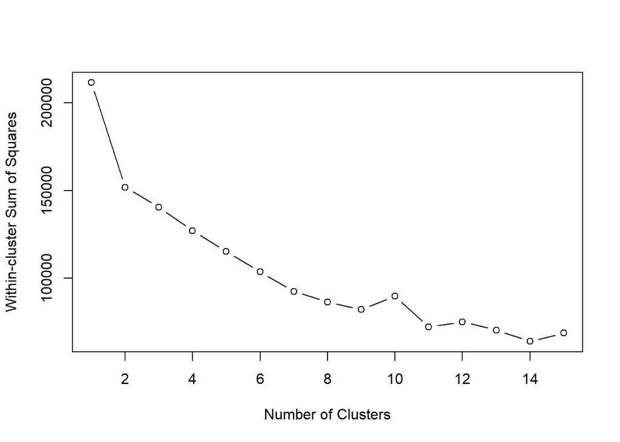

```r
# Plot the Elbow graph
plot(1:15, wcss, type = "b", xlab = "Number of Clusters", ylab = "Within-cluster Sum of Squares")
```

```r
set.seed(22)

kpres <- kproto(g1_m_cluster_0, k = 9)  # Adjust 'k' to the desired number of clusters
```

```
## # NAs in variables:
##       FREQUENT_ORDER_TYPE        COLD_DRINK_CHANNEL Has.Primary.Group.Number.
##                         0                         0                         0
##             TRADE_CHANNEL         SUB_TRADE_CHANNEL                 AGI_GROUP
##                         0                         0                         0
##      Average_Growth_Index
##                         0
## 0 observation(s) with NAs.
##
## Estimated lambda: 89.3292
```

```r
summary(kpres)
```

```
## FREQUENT_ORDER_TYPE
##
## cluster CALL CENTER   EDI MYCOKE LEGACY MYCOKE360 OTHER SALES REP
##       1       0.000 0.000         0.019     0.113 0.547     0.321
##       2       0.019 0.000         0.031     0.000 0.025     0.925
##       3       0.025 0.000         0.025     0.025 0.076     0.849
##       4       0.000 0.000         0.000     0.133 0.867     0.000
##       5       0.033 0.000         0.008     0.025 0.000     0.933
##       6       0.030 0.000         0.030     0.091 0.424     0.424
##       7       0.196 0.000         0.039     0.529 0.235     0.000
##       8       0.012 0.000         0.024     0.082 0.047     0.835
##       9       0.028 0.000         0.037     0.056 0.130     0.750
##
## -----------------------------------------------------------------
## COLD_DRINK_CHANNEL
```

[output cut: 290 more lines]

```r
g1_m_cluster_0$Cluster <- kpres$cluster
```

```r
# Write cluster outputs to text file
#summary_output_g1mc_0 <- capture.output(summary(kpres))


#writeLines(summary_output, "cluster_summary_g1m_0.txt")

# View the first few rows of the data frame
#head(g1_m_cluster)
```

```r
# Cluster for all customers within threshold and AGI = 1
g2_m_cluster_1 <- g2_m_agi |>
  select(FREQUENT_ORDER_TYPE, COLD_DRINK_CHANNEL, Has.Primary.Group.Number.,
         TRADE_CHANNEL, SUB_TRADE_CHANNEL, AGI_GROUP, Average_Growth_Index) |>
  filter(AGI_GROUP == 1)

# Scale numerical variables using min-max scaling
#g2_m_cluster <- g2_m_cluster |>
  #mutate(Average_Growth_Index = (Average_Growth_Index - min(Average_Growth_Index)) / (max(Average_Growth_Index) - min(Average_Growth_Index)))
```

```r
# Calculate WCSS for different numbers of clusters
wcss <- numeric(15)
for (k in 1:15) {
  kpres <- kproto(g2_m_cluster_1, k)
  wcss[k] <- kpres$tot.withinss
}
```

[output not shown]

[output cut: 21 more lines]

[output not shown]

```
## Equal prototypes merged. Cluster number reduced to:6
```

[output not shown]

[output cut: 32 more lines]

[output not shown]

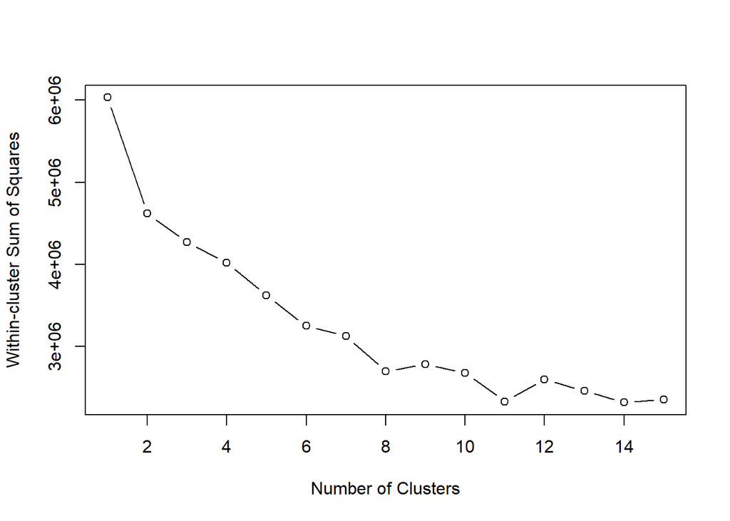

```r
# Plot the Elbow graph
plot(1:15, wcss, type = "b", xlab = "Number of Clusters", ylab = "Within-cluster Sum of Squares")
```

```r
kpres <- kproto(g2_m_cluster_1, k = 8)  # Adjust 'k' to the desired number of clusters
```

```
## # NAs in variables:
##       FREQUENT_ORDER_TYPE        COLD_DRINK_CHANNEL Has.Primary.Group.Number.
##                         0                         0                         0
##             TRADE_CHANNEL         SUB_TRADE_CHANNEL                 AGI_GROUP
##                         0                         0                         0
##      Average_Growth_Index
##                         0
## 0 observation(s) with NAs.
##
## Estimated lambda: 295.3044
```

```r
summary(kpres)
```

```
## FREQUENT_ORDER_TYPE
##
## cluster CALL CENTER   EDI MYCOKE LEGACY MYCOKE360 OTHER SALES REP
##       1       0.027 0.002         0.008     0.059 0.205     0.698
##       2       0.022 0.000         0.015     0.034 0.132     0.797
##       3       0.035 0.000         0.016     0.089 0.166     0.694
##       4       0.034 0.000         0.013     0.063 0.226     0.664
##       5       0.057 0.000         0.009     0.035 0.189     0.711
##       6       0.033 0.000         0.011     0.077 0.198     0.681
##       7       0.026 0.000         0.019     0.092 0.257     0.606
##       8       0.030 0.000         0.005     0.089 0.238     0.639
##
## -----------------------------------------------------------------
## COLD_DRINK_CHANNEL
##
```

[output cut: 264 more lines]

```r
g2_m_cluster_1$Cluster <- kpres$cluster
```

```r
summary_output_g2mc_1 <- capture.output(summary(kpres))


writeLines(summary_output_g2mc_1, "cluster_summary_g2m_1.txt")

# View the first few rows of the data frame
#head(g1_m_cluster)
```

```r
# Create boxplot
#ggplot(g2_m_cluster, aes(x = factor(Cluster), y = Average_Growth_Index)) +
  #geom_boxplot() +
  #labs(x = "Cluster Number", y = "AGI") +
  #theme_minimal()
```

```r
#ggplot(g2_m_cluster, aes(x = FREQUENT_ORDER_TYPE, y = Average_Growth_Index, color = factor(Cluster))) +
  #geom_point() +
  #labs(x = "FREQUENT_ORDER_TYPE", y = "AGI", color = "Cluster") +
  #theme_minimal()
```

```r
# Cluster for all within threshold and AGI < 0
g2_m_cluster_0<- g2_m_agi |>
  select(FREQUENT_ORDER_TYPE, COLD_DRINK_CHANNEL, Has.Primary.Group.Number.,
         TRADE_CHANNEL, SUB_TRADE_CHANNEL, AGI_GROUP, Average_Growth_Index) |>
  filter(AGI_GROUP == 0)

# Scale numerical variables using min-max scaling
#g2_m_cluster <- g2_m_cluster |>
  #mutate(Average_Growth_Index = (Average_Growth_Index - min(Average_Growth_Index)) / (max(Average_Growth_Index) - min(Average_Growth_Index)))
```

```r
# Calculate WCSS for different numbers of clusters
wcss <- numeric(15)
for (k in 1:15) {
  kpres <- kproto(g2_m_cluster_0, k)
  wcss[k] <- kpres$tot.withinss
}
```

[output not shown]

[output cut: 109 more lines]

[output not shown]

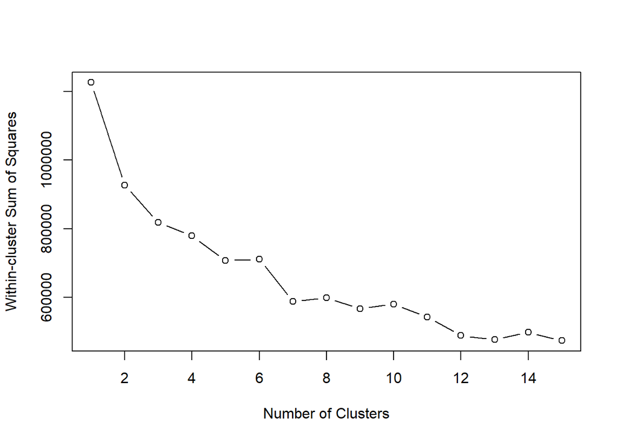

```r
# Plot the Elbow graph
plot(1:15, wcss, type = "b", xlab = "Number of Clusters", ylab = "Within-cluster Sum of Squares")
```

```r
kpres <- kproto(g2_m_cluster_0, k = 7)  # Adjust 'k' to the desired number of clusters
```

```
## # NAs in variables:
##       FREQUENT_ORDER_TYPE        COLD_DRINK_CHANNEL Has.Primary.Group.Number.
##                         0                         0                         0
##             TRADE_CHANNEL         SUB_TRADE_CHANNEL                 AGI_GROUP
##                         0                         0                         0
##      Average_Growth_Index
##                         0
## 0 observation(s) with NAs.
##
## Estimated lambda: 81.16351
```

```r
summary(kpres)
```

```
## FREQUENT_ORDER_TYPE
##
## cluster CALL CENTER   EDI MYCOKE LEGACY MYCOKE360 OTHER SALES REP
##       1       0.030 0.000         0.010     0.089 0.096     0.776
##       2       0.023 0.000         0.016     0.043 0.918     0.000
##       3       0.060 0.000         0.013     0.030 0.164     0.732
##       4       0.033 0.000         0.020     0.064 0.158     0.724
##       5       0.022 0.000         0.011     0.051 0.000     0.916
##       6       0.026 0.000         0.019     0.090 0.619     0.246
##       7       0.030 0.000         0.018     0.059 0.124     0.769
##
## -----------------------------------------------------------------
## COLD_DRINK_CHANNEL
##
## cluster ACCOMMODATION BULK TRADE CONVENTIONAL DINING EVENT GOODS PUBLIC SECTOR
```

[output cut: 238 more lines]

```r
g2_m_cluster_0$Cluster <- kpres$cluster
```

```r
#summary_output_g2mc_0 <- capture.output(summary(kpres))


#writeLines(summary_output_g2mc_0, "cluster_summary_g2m_0.txt")

# View the first few rows of the data frame
#head(g1_m_cluster)
```

## Within Threshold Cluster Analysis

### Clusters for LMP gallon-only customers with declining orders (AGI Group = 0)

#### Clusters 1 and 8 have the highest (negative) mean AGI values (-30% and -24%). We will emphasize these clusters in terms of their customer demographics as our “exclusion group”. In other words, these are customers who should be offboarded from the red truck program. This interpretation is applicable to further analysis of clusters within this AGI group.

#### Frequent Order Type Proportions: For cluster 1, ~55% of customers place orders through “other” means. For cluster 8, ~84% of customers place orders through sales reps.

#### Cold Drink Channel Proportions: For cluster 1, ~87% of customers are within the dining channel. For cluster 8, ~81% of customers are also within the dining channel.

#### Trade Channel Proportions: For cluster 1, ~76% of customers are within the “fast casual dining” channel. For cluster 8, 46% of customers are within the “licensed hospitality” channel.

#### Sub-Trade Channel Proportions: For cluster 1, 36% of customers belong to the “other fast food” channel. For cluster 8, ~18% are within the “other dining” channel.

### Clusters for all customers with positive growth (AGI Group = 1)

#### Clusters 1 and 4 have the highest AGI values (~67% and ~42%).

#### Frequent Order Type Proportions: For cluster 1, ~70% of customers place orders through sales reps. For cluster 4, 66% of customers also place orders through sales reps.

#### Cold Drink Channel Proportions: For cluster 1, 69% of customers are within the dining channel. For cluster 4, 68% of customers are also within the dining channel.

#### Trade Channel Proportions: For cluster 1, 40% of customers are within the “comprehensive dining” channel. For cluster 4, 53% of customers are within the “fast casual dining” channel.

#### Sub-Trade Channel Proportions: For cluster 1, 40% of customers belong to the “FSR-MISC” channel. For cluster 4, 17% are within the “Mexican fast food” channel.

### Clusters for all customers with declining orders (AGI Group = 0)

#### Clusters 1 and 4 have the highest (negative) mean AGI values (-13% and -26%).

#### Frequent Order Type Proportions: For cluster 1, 78% of customers place orders through sales reps. For cluster 4, 72% of customers also place orders through sales reps.

#### Cold Drink Channel Proportions: For cluster 1, 62% of customers are within the event channel. For cluster 4, 75% of customers are within the dining channel.

#### Trade Channel Proportions: For cluster 1, 53% of customers are within the “outdoor activities” channel. For cluster 4, 24% of customers are within the “other dining and beverage” channel.

#### Sub-Trade Channel Proportions: For cluster 1, 50% of customers belong to the “other outdoor activities” channel. For cluster 4, 19% are within the “FSR-MISC” channel.

# K - Prototype Clustering for Customers Ordering Beyond Threshold

```r
# Cluster for ALL beyond threshold
g2_op_m_cluster <- g2_m |>
  select(FREQUENT_ORDER_TYPE, COLD_DRINK_CHANNEL, Has.Primary.Group.Number.,
         TRADE_CHANNEL, SUB_TRADE_CHANNEL, MONTHLY_TOTAL) |>
  filter(MONTHLY_TOTAL >= 33.3)

# Scale numerical variables using min-max scaling
#g2_op_m_cluster <- g2_op_m_cluster |>
  #mutate(MONTHLY_TOTAL = (MONTHLY_TOTAL - min(MONTHLY_TOTAL)) / (max(MONTHLY_TOTAL) - min(MONTHLY_TOTAL)))
```

```r
wcss <- numeric(15)
for (k in 1:15) {
  kpres <- kproto(g2_op_m_cluster, k)
  wcss[k] <- kpres$tot.withinss
}
```

[output not shown]

[output cut: 43 more lines]

[output not shown]

```
## Equal prototypes merged. Cluster number reduced to:10
```

[output not shown]

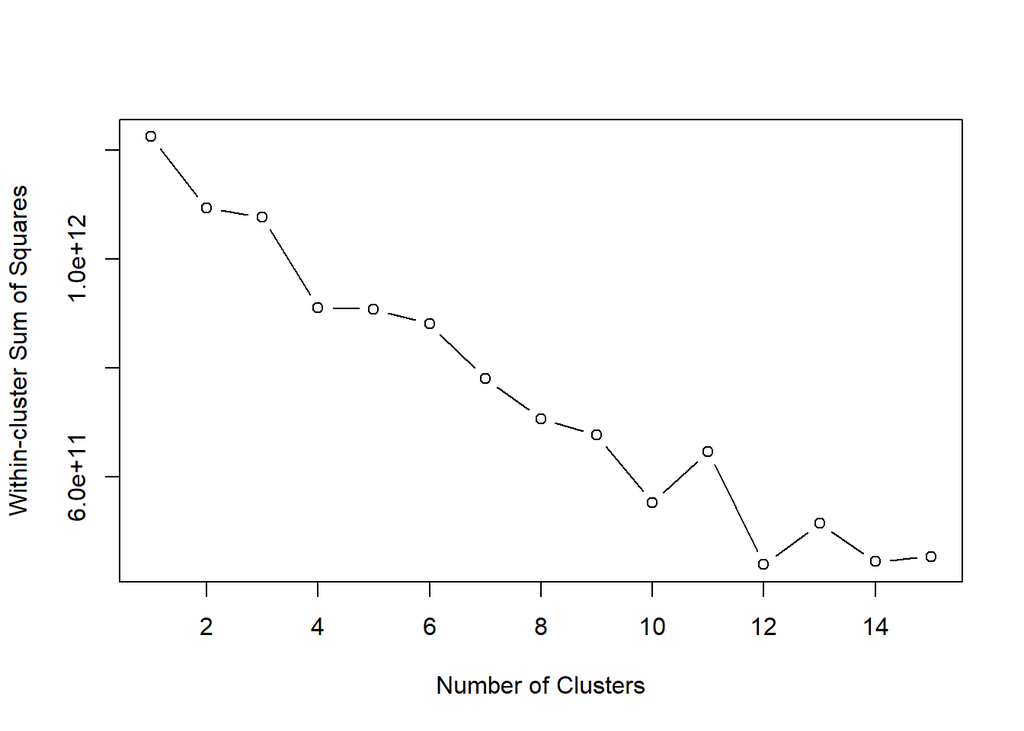

```r
# Plot the Elbow graph
plot(1:15, wcss, type = "b", xlab = "Number of Clusters", ylab = "Within-cluster Sum of Squares")
```

```r
kpres <- kproto(g2_op_m_cluster, k = 10)
```

```
## # NAs in variables:
##       FREQUENT_ORDER_TYPE        COLD_DRINK_CHANNEL Has.Primary.Group.Number.
##                         0                         0                         0
##             TRADE_CHANNEL         SUB_TRADE_CHANNEL             MONTHLY_TOTAL
##                         0                         0                         0
## 0 observation(s) with NAs.
##
## Estimated lambda: 2799186
```

```r
summary(kpres)
```

```
## FREQUENT_ORDER_TYPE
##
## cluster CALL CENTER   EDI MYCOKE LEGACY MYCOKE360 OTHER SALES REP
##      1        0.010 0.005         0.011     0.043 0.132     0.798
##      2        0.021 0.001         0.021     0.054 0.035     0.869
##      3        0.003 0.000         0.202     0.016 0.022     0.757
##      4        0.014 0.000         0.010     0.092 0.189     0.695
##      5        0.011 0.028         0.003     0.056 0.136     0.765
##      6        0.005 0.000         0.003     0.037 0.143     0.812
##      7        0.022 0.001         0.006     0.030 0.857     0.084
##      8        0.020 0.000         0.005     0.029 0.144     0.801
##      9        0.014 0.002         0.011     0.084 0.209     0.681
##      10       0.057 0.062         0.004     0.050 0.088     0.739
##
## -----------------------------------------------------------------
```

[output cut: 302 more lines]

```r
g2_op_m_cluster$Cluster <- kpres$cluster
```

```r
#summary_output_g2op_m <- capture.output(summary(kpres))


#writeLines(summary_output_g2op_m, "cluster_summary_g2op_m.txt")

# View the first few rows of the data frame
#head(g1_m_cluster)
```

```r
# Create boxplot
#ggplot(g2_op_m_cluster, aes(x = factor(Cluster), y = MONTHLY_TOTAL)) +
  #geom_boxplot() +
  #labs(x = "Cluster Number", y = "Monthly Total") +
  #theme_minimal()
```

```r
# Cluster for LMP beyond threshold
g1_op_m_cluster <- g1_m |>
  select(FREQUENT_ORDER_TYPE, COLD_DRINK_CHANNEL, Has.Primary.Group.Number.,
         TRADE_CHANNEL, SUB_TRADE_CHANNEL, ORDERED_GALLONS) |>
  filter(ORDERED_GALLONS >= 33.3)

# Scale numerical variables using min-max scaling
#g1_op_m_cluster <- g1_op_m_cluster |>
  #mutate(MONTHLY_TOTAL = (MONTHLY_TOTAL - min(MONTHLY_TOTAL)) / (max(MONTHLY_TOTAL) - min(MONTHLY_TOTAL)))
```

```r
wcss <- numeric(15)
for (k in 1:15) {
  kpres <- kproto(g1_op_m_cluster, k)
  wcss[k] <- kpres$tot.withinss
}
```

[output not shown]

[output cut: 52 more lines]

[output not shown]

```
## Equal prototypes merged. Cluster number reduced to:11
```

[output not shown]

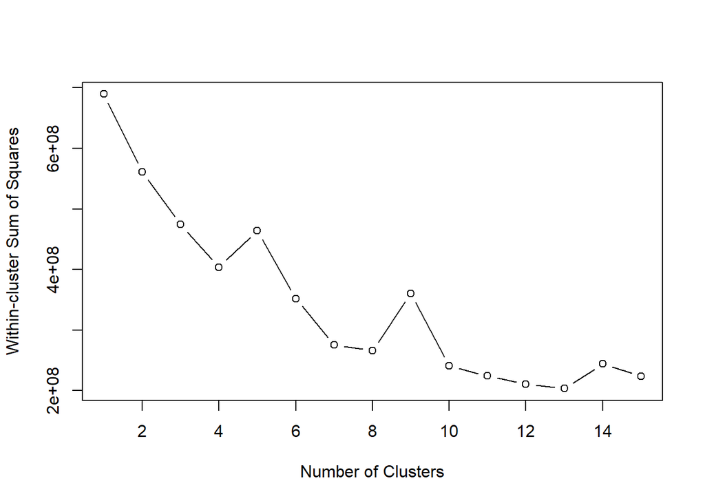

```r
# Plot the Elbow graph
plot(1:15, wcss, type = "b", xlab = "Number of Clusters", ylab = "Within-cluster Sum of Squares")
```

```r
kpres <- kproto(g1_op_m_cluster, k = 7)
```

```
## # NAs in variables:
##       FREQUENT_ORDER_TYPE        COLD_DRINK_CHANNEL Has.Primary.Group.Number.
##                         0                         0                         0
##             TRADE_CHANNEL         SUB_TRADE_CHANNEL           ORDERED_GALLONS
##                         0                         0                         0
## 0 observation(s) with NAs.
##
## Estimated lambda: 30156.86
```

```r
summary(kpres)
```

```
## FREQUENT_ORDER_TYPE
##
## cluster CALL CENTER   EDI MYCOKE LEGACY MYCOKE360 OTHER SALES REP
##       1       0.533 0.000         0.095     0.372 0.000     0.000
##       2       0.020 0.000         0.017     0.063 0.186     0.714
##       3       0.000 0.000         0.002     0.017 0.981     0.000
##       4       0.000 0.000         0.001     0.010 0.000     0.989
##       5       0.000 0.000         0.035     0.045 0.166     0.753
##       6       0.010 0.000         0.008     0.043 0.099     0.840
##       7       0.000 0.000         0.000     0.054 0.157     0.789
##
## -----------------------------------------------------------------
## COLD_DRINK_CHANNEL
##
## cluster ACCOMMODATION BULK TRADE CONVENTIONAL DINING EVENT GOODS PUBLIC SECTOR
```

[output cut: 227 more lines]

```r
g1_op_m_cluster$Cluster <- kpres$cluster
```

```r
#summary_output_g1op_m <- capture.output(summary(kpres))


#writeLines(summary_output_g1op_m, "cluster_summary_g1op_m.txt")
```

## Beyond Threshold Cluster Analysis

#### This analysis is for customers who are already exceeding the existing 400 gallon/year threshold. As such, it is emphasized on monthly order volumes rather than growth index.

### Clusters for all customers beyond the yearly threshold.

#### Clusters 3 and 5 have the highest average monthly orders (1,115 and 539 gallons/month)

#### Frequent Order Type Proportions: For cluster 3, 76% of customers place orders through sales reps. For cluster 5, 77% of customers also place orders through sales reps.

#### Cold Drink Channel Proportions: For cluster 3, 87% of customers are within the dining channel. For cluster 5, 95% of customers are within the bulk trade channel.

#### Trade Channel Proportions: For cluster 3, 87% of customers are within the “fast casual dining” channel. For cluster 5, 83% of customers are within the “general” channel.

#### Sub-Trade Channel Proportions: For cluster 3, 85% of customers belong to the “pizza fast food” channel. For cluster 5, 82% are within the “comprehensive provider” channel.

### Clusters for LMP gallon-only customers beyond the yearly threshold.

#### Clusters 4 and 7 have the highest average monthly orders (108 and 731 gallons/month)

#### Frequent Order Type Proportions: For cluster 4, 99% of customers place orders through sales reps. For cluster 7, 79% of customers also place orders through sales reps.

#### Cold Drink Channel Proportions: For cluster 4, 99% of customers are within the dining channel. For cluster 7, 77% of customers are also within the dining channel.

#### Trade Channel Proportions: For cluster 4, 93% of customers are within the “comprehensive dining” channel. For cluster 7, 44% of customers are also within the “comprehensive dining” channel.

#### Sub-Trade Channel Proportions: For cluster 4, 93% of customers belong to the “FSR-MISC” channel. For cluster 4, 44% are also within this channel.

# Density Based Clustering for Customer Yearly Orders

```r
# For LMP yearly orders
g1_y_geo <- aggregate(TOTAL_YEAR_ORDERS ~ LATITUDE + LONGITUDE + AGI_GROUP, data = g1_y, sum)

g1_y_geo <- g1_y_geo |>
  filter(TOTAL_YEAR_ORDERS <= 400)

# Ensure the data is in the correct format
data_matrix <- as.matrix(g1_y_geo[, c("LATITUDE", "LONGITUDE")])

# Set parameters for DBSCAN
eps <- 1 # Maximum distance between two points to be considered in the same neighborhood
minPts <- 10 # Minimum number of points to form a dense region

# Perform DBSCAN clustering
dbscan_result <- dbscan(data_matrix, eps = eps, minPts = minPts)

# Add cluster assignments to the data frame
g1_y_geo$Cluster <- dbscan_result$cluster
```

```r
# Convert to spatial data frame
g1_y_zips_sf <- st_as_sf(g1_y_geo, coords = c("LATITUDE", "LONGITUDE"), crs = 4326)
```

```r
us_map <- map_data("state")
```

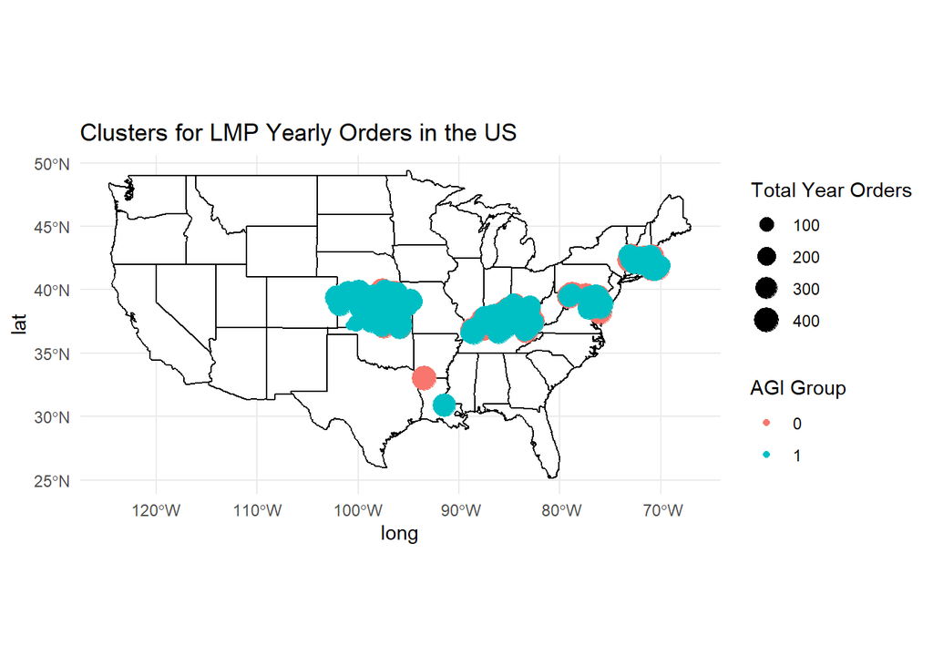

```r
ggplot() +
  geom_polygon(data = us_map, aes(x = long, y = lat, group = group), fill = "white", color = "black") +
  geom_sf(data = g1_y_zips_sf, aes(size = TOTAL_YEAR_ORDERS, color = as.factor(AGI_GROUP))) +
  labs(color = "AGI Group", size = "Total Year Orders", title = "Clusters for LMP Yearly Orders in the US") +
  theme_minimal()
```

### We can see that customer data exists within only 5 states.

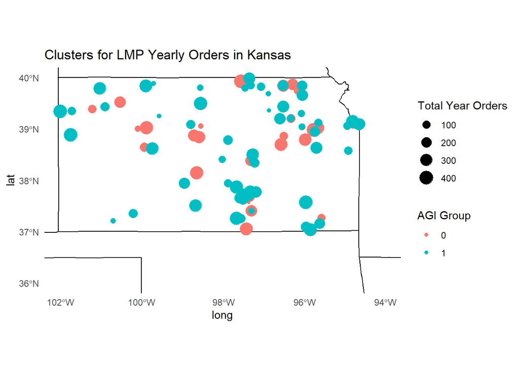

```r
# Plot for  Kansas customers
ggplot() +
  geom_polygon(data = us_map, aes(x = long, y = lat, group = group), fill = "white", color = "black") +
  geom_sf(data = g1_y_zips_sf, aes(size = TOTAL_YEAR_ORDERS, color = as.factor(AGI_GROUP))) +
  coord_sf(xlim = c(-102, -94), ylim = c(36, 40)) +  # Adjust these limits as needed
  labs(color = "AGI Group", size = "Total Year Orders", title = "Clusters for LMP Yearly Orders in Kansas") +
  theme_minimal()
```

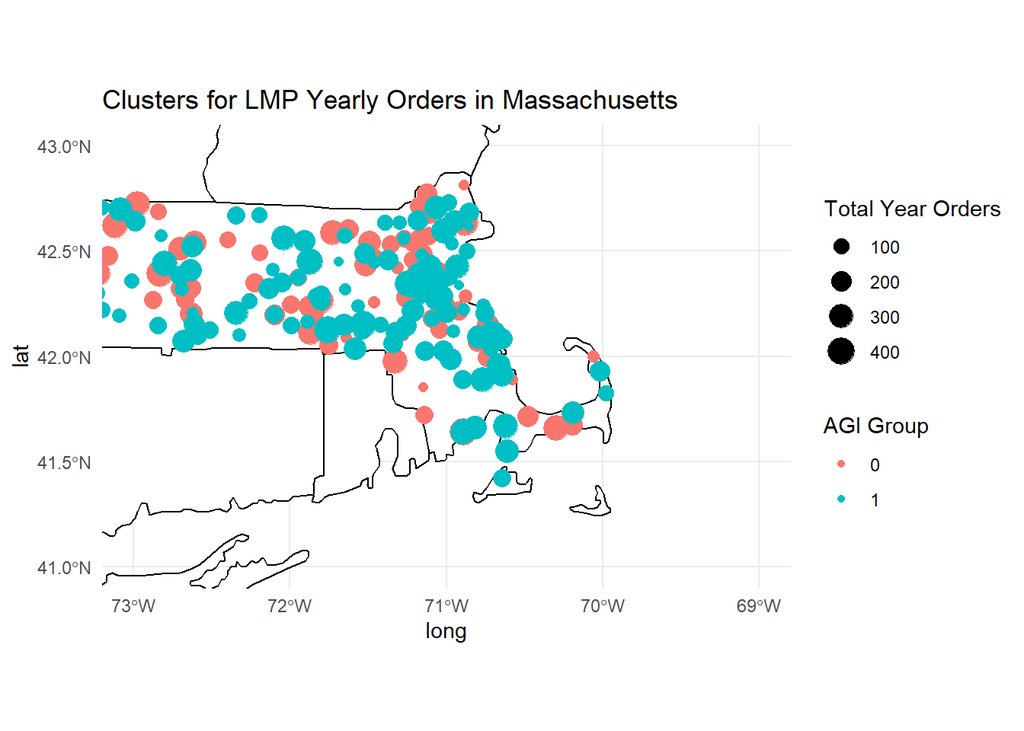

```r
ggplot() +
  geom_polygon(data = us_map, aes(x = long, y = lat, group = group), fill = "white", color = "black") +
  geom_sf(data = g1_y_zips_sf, aes(size = TOTAL_YEAR_ORDERS, color = as.factor(AGI_GROUP))) +
  coord_sf(xlim = c(-73, -69), ylim = c(41, 43)) +  # Adjusted limits for Massachusetts
  labs(color = "AGI Group", size = "Total Year Orders", title = "Clusters for LMP Yearly Orders in Massachusetts") +
  theme_minimal()
```

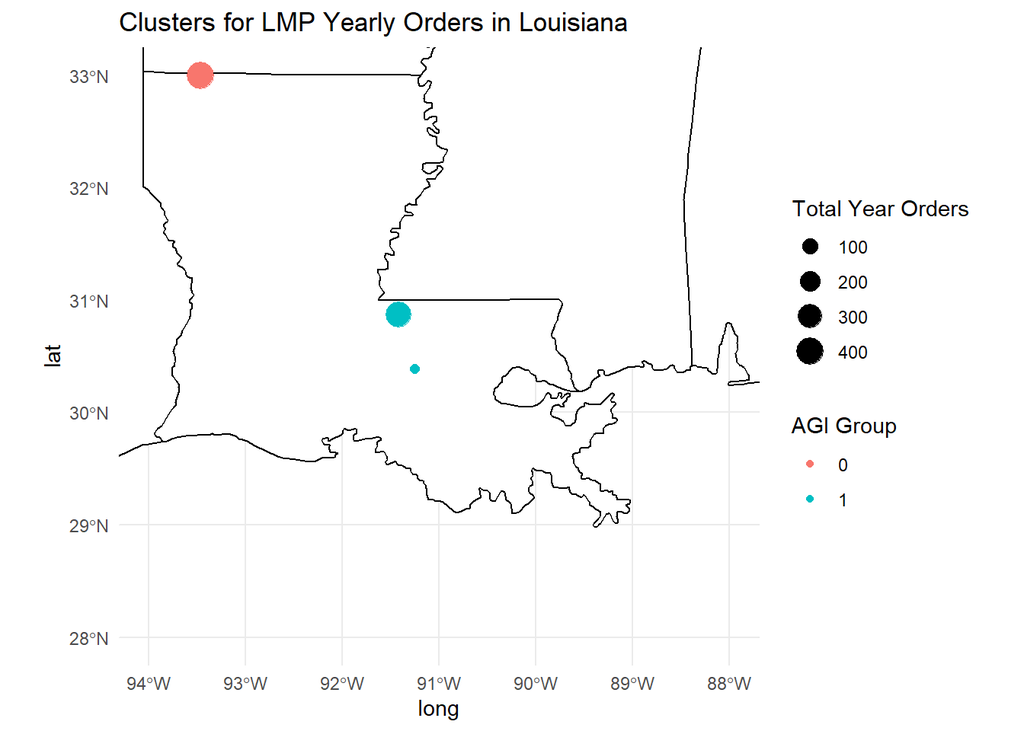

```r
ggplot() +
  geom_polygon(data = us_map, aes(x = long, y = lat, group = group), fill = "white", color = "black") +
  geom_sf(data = g1_y_zips_sf, aes(size = TOTAL_YEAR_ORDERS, color = as.factor(AGI_GROUP))) +
  coord_sf(xlim = c(-94, -88), ylim = c(28, 33)) +  # Adjusted limits for Louisiana
  labs(color = "AGI Group", size = "Total Year Orders", title = "Clusters for LMP Yearly Orders in Louisiana") +
  theme_minimal()
```

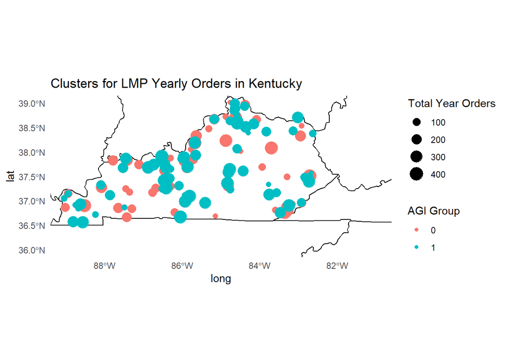

```r
ggplot() +
  geom_polygon(data = us_map, aes(x = long, y = lat, group = group), fill = "white", color = "black") +
  geom_sf(data = g1_y_zips_sf, aes(size = TOTAL_YEAR_ORDERS, color = as.factor(AGI_GROUP))) +
  coord_sf(xlim = c(-89, -81), ylim = c(36, 39)) +  # Adjusted limits for Kentucky
  labs(color = "AGI Group", size = "Total Year Orders", title = "Clusters for LMP Yearly Orders in Kentucky") +
  theme_minimal()
```

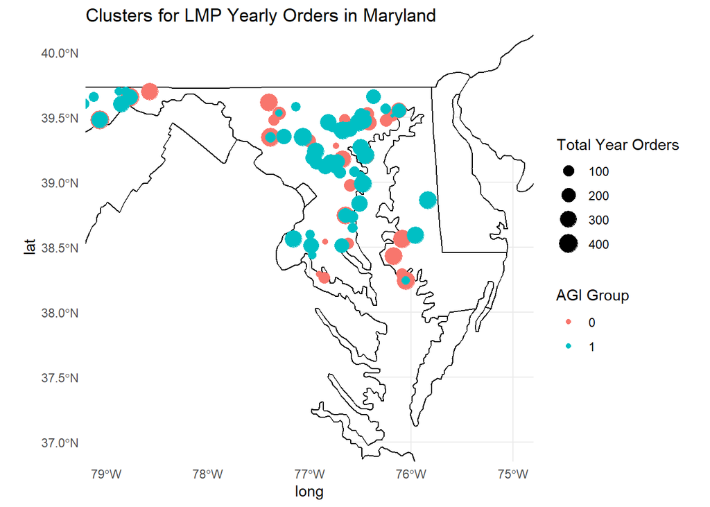

```r
ggplot() +
  geom_polygon(data = us_map, aes(x = long, y = lat, group = group), fill = "white", color = "black") +
  geom_sf(data = g1_y_zips_sf, aes(size = TOTAL_YEAR_ORDERS, color = as.factor(AGI_GROUP))) +
  coord_sf(xlim = c(-79, -75), ylim = c(37, 40)) +  # Adjusted limits for Maryland
  labs(color = "AGI Group", size = "Total Year Orders", title = "Clusters for LMP Yearly Orders in Maryland") +
  theme_minimal()
```

```r
# For all yearly orders
g2_y_geo <- aggregate(TOTAL_YEAR_ORDERS ~ LATITUDE + LONGITUDE + AGI_GROUP, data = g2_y, sum)

g2_y_geo <- g2_y_geo |>
  filter(TOTAL_YEAR_ORDERS <= 400)

g2data_matrix <- as.matrix(g2_y_geo[, c("LATITUDE", "LONGITUDE")])

# Set parameters for DBSCAN
g2eps <- 0.5  # Maximum distance between two points to be considered in the same neighborhood
g2minPts <- 5  # Minimum number of points to form a dense region

g2dbscan_result <- dbscan(g2data_matrix, eps = g2eps, minPts = g2minPts)

g2_y_geo$Cluster <- g2dbscan_result$cluster
```

```r
g2_y_zips_sf <- st_as_sf(g2_y_geo, coords = c("LATITUDE", "LONGITUDE"), crs = 4326)
```

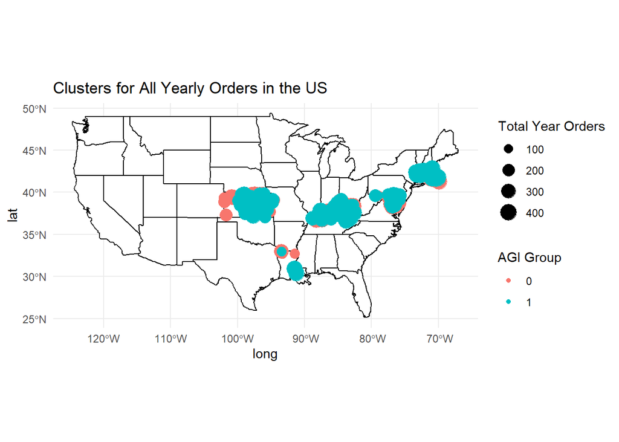

```r
ggplot() +
  geom_polygon(data = us_map, aes(x = long, y = lat, group = group), fill = "white", color = "black") +
  geom_sf(data = g2_y_zips_sf, aes(size = TOTAL_YEAR_ORDERS, color = as.factor(AGI_GROUP))) +
  labs(color = "AGI Group", size = "Total Year Orders", title = "Clusters for All Yearly Orders in the US") +
  theme_minimal()
```

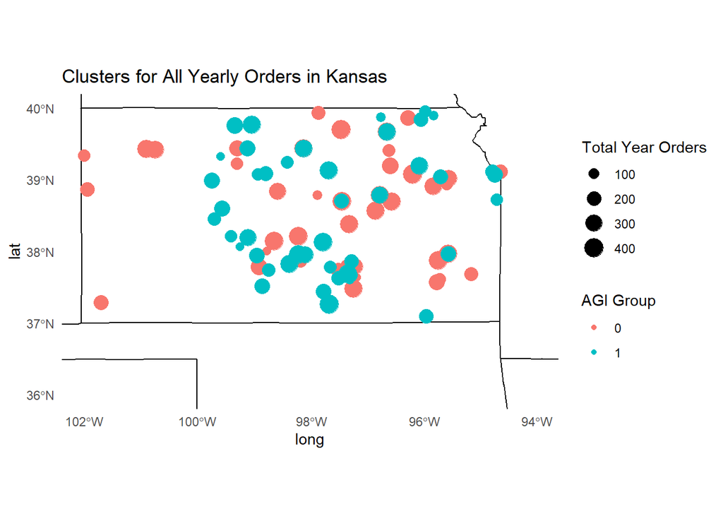

```r
ggplot() +
  geom_polygon(data = us_map, aes(x = long, y = lat, group = group), fill = "white", color = "black") +
  geom_sf(data = g2_y_zips_sf, aes(size = TOTAL_YEAR_ORDERS, color = as.factor(AGI_GROUP))) +
  coord_sf(xlim = c(-102, -94), ylim = c(36, 40)) +  # Adjust these limits as needed
  labs(color = "AGI Group", size = "Total Year Orders", title = "Clusters for All Yearly Orders in Kansas") +
  theme_minimal()
```

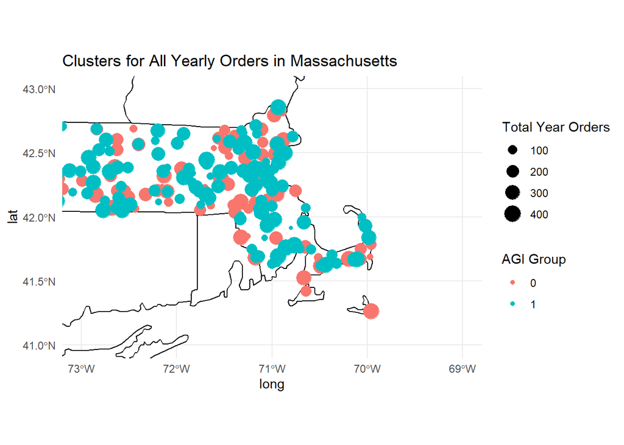

```r
ggplot() +
  geom_polygon(data = us_map, aes(x = long, y = lat, group = group), fill = "white", color = "black") +
  geom_sf(data = g2_y_zips_sf, aes(size = TOTAL_YEAR_ORDERS, color = as.factor(AGI_GROUP))) +
  coord_sf(xlim = c(-73, -69), ylim = c(41, 43)) +  # Adjusted limits for Massachusetts
  labs(color = "AGI Group", size = "Total Year Orders", title = "Clusters for All Yearly Orders in Massachusetts") +
  theme_minimal()
```

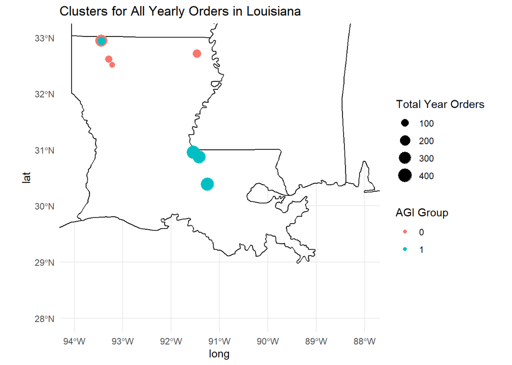

```r
ggplot() +
  geom_polygon(data = us_map, aes(x = long, y = lat, group = group), fill = "white", color = "black") +
  geom_sf(data = g2_y_zips_sf, aes(size = TOTAL_YEAR_ORDERS, color = as.factor(AGI_GROUP))) +
  coord_sf(xlim = c(-94, -88), ylim = c(28, 33)) +  # Adjusted limits for Louisiana
  labs(color = "AGI Group", size = "Total Year Orders", title = "Clusters for All Yearly Orders in Louisiana") +
  theme_minimal()
```

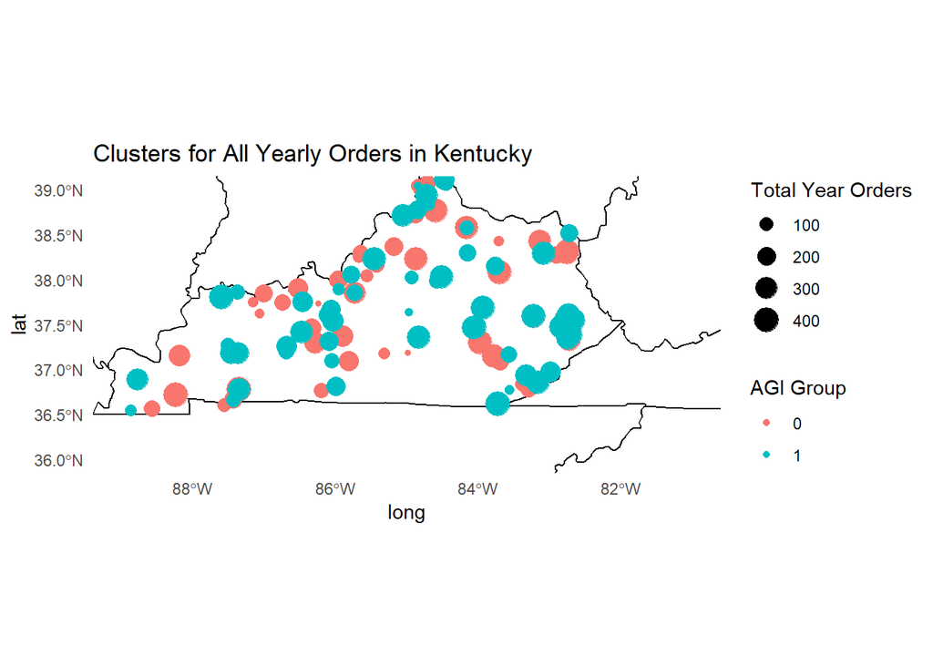

```r
ggplot() +
  geom_polygon(data = us_map, aes(x = long, y = lat, group = group), fill = "white", color = "black") +
  geom_sf(data = g2_y_zips_sf, aes(size = TOTAL_YEAR_ORDERS, color = as.factor(AGI_GROUP))) +
  coord_sf(xlim = c(-89, -81), ylim = c(36, 39)) +  # Adjusted limits for Kentucky
  labs(color = "AGI Group", size = "Total Year Orders", title = "Clusters for All Yearly Orders in Kentucky") +
  theme_minimal()
```

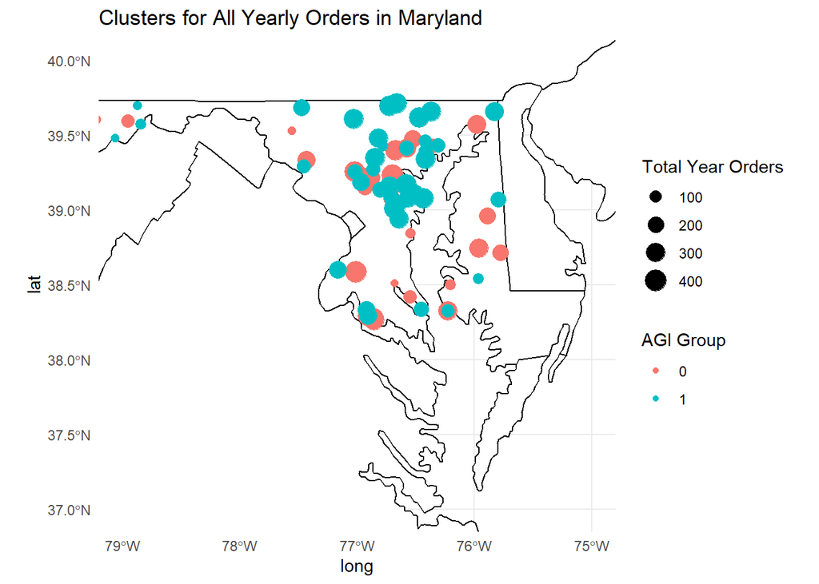

```r
ggplot() +
  geom_polygon(data = us_map, aes(x = long, y = lat, group = group), fill = "white", color = "black") +
  geom_sf(data = g2_y_zips_sf, aes(size = TOTAL_YEAR_ORDERS, color = as.factor(AGI_GROUP))) +
  coord_sf(xlim = c(-79, -75), ylim = c(37, 40)) +  # Adjusted limits for Maryland
  labs(color = "AGI Group", size = "Total Year Orders", title = "Clusters for All Yearly Orders in Maryland") +
  theme_minimal()
```

## Density Based Cluster Analysis

#### These clusters are plotted according to geographical locations of customers who are below the 400 gallon threshold. The plot color indicates customers with positive AGI (blue) and negative AGI (red). It is anticipated that these plots can be used to segment low yearly volume customers who also show decline in order volume, and decide whether or not it would be logistically efficient to continue serving them via red truck service depending on their relative distance from “hubs” of customers who will most likely continue to be served on the red truck service. In contrast, customers with both high growth potential and close proximity to each other can be most easily served with the red truck distribution service, and should be considered to be kept on this service.